# Technoecom: Digital Transformation - Project 1

### Business Context:

In the contemporary era, electronic devices have become an integral part of everyday life, ranging from basic LED lights to cutting-edge laptops and 4K televisions. With such widespread demand for these products, many entrepreneurs have ventured into the electronic goods and services sector. Technoecom stands out as one of Australia's premier direct-to-consumer retailers in this domain. Offering an extensive array of over 500 top-notch electronic products sourced from global manufacturers, the company caters to diverse consumer needs across various categories.

Their product range spans gaming devices, accessories, wireless speakers, smartphones, laptop peripherals, entertainment systems, and high-end home appliances from luxury brands. Operating in more than 10 cities, Technoecom ensures nationwide accessibility by delivering products directly to customers' doorsteps.

In a strategic move towards digital transformation, the company has recently launched its e-commerce platform. This initiative aims to pilot sales and delivery operations through the online platform for a duration of three months, reflecting their commitment to staying at the forefront of technological advancements in retail.

### Problem Statement:

Transitioning to conducting business via an e-commerce platform has proven to be a challenging endeavor. Over the course of the past three months, Technoecom has encountered numerous obstacles spanning different areas, including payment methods, order volume, geographical coverage, expedited shipping, and customer satisfaction. Now, the company is seeking to assess the feasibility of expanding this digital transformation to additional cities and to evaluate the revenue generated from this pilot program.

### Objective:

The Chief Experience Officer (CXO) is keen on enhancing monitoring and diagnostic capabilities to ensure the company makes informed decisions. As the analytics lead, your role is to conduct data preprocessing and exploratory data analysis (EDA) to gain insights into the digital transformation initiative and submit a detailed analysis report. This report will provide the necessary information for the CXO to make informed decisions regarding the potential expansion of this digital transformation to other cities.

**Submission Guidelines:**

There are two files that are expected to be submitted for the project a notebook and report

1. Use the technoecom_project_learner_notebook.ipynb to write codes.
2. Use the technoecom_project_sample_report.pptx
3. Submit the final Jupyter notebook in HTML format with all the insights and observations
4. Use these link to convert the notebook in to HTML format, upload the file and download the html version of notebook and submit on the portal
5. Please follow the below steps to complete Project-1 and make sure that all the sections mentioned in the rubric have been covered in your submission.
   1. Download the learner's notebook.
   2. Follow the instructions provided in the notebook to complete the Project.
   3. Clearly, write down insights and recommendations for the business problems in the comments.
6. Any notebook or report discovered to be copied or plagiarised with other submissions will not be graded and will receive zero points.
7. Please ensure timely submission as any submission made post-deadline will not be accepted for evaluation.

**Best Practices for notebook**

- The final notebook should be well-documented, with inline comments explaining the functionality of code and markdown cells containing comments on the observations and insights.
- The notebook should be run from start to finish in a sequential manner before submission.
- It is important to remove all warnings and errors before submission.
- The notebook should be submitted as an HTML file not as an notebook file (.ipynb)

**Best Practices for Report/Presentation:**

- The report should be made keeping in mind that the audience will be the CXOs of the Company or Business Stakeholders..
- The key points in the report should be the following:
  - Business Overview of the problem and solution approach
  - Key findings and insights in each section
  - Business recommendations that can drive decisions
- Focus on explaining the key takeaways in an easy-to-understand manner
- The **Quarterly Report** should be submitted as a **.pdf** file

A business report template has been provided for reference. It is **not** mandatory to make your presentation in the same style or manner as this sample report. You can get creative!

**Power Ahead!**

**Scoring guide (Rubric) - Project -1: Technoecom: Digital Transformation**

## **Step 1: Data Import**

- Import the required libraries [1 Points] - Import the dataset [1 Points]

  ```
  Total [2 Points]
  ```

## **Step 2: Understanding the data**

- Shape of the data [1 Points] - Display the datatypes, and correct the datatypes if any. [1 Points] - Check the statistical summary and write down the observations. [1 Points]

  ```
  Total [3 Points]
  ```

## **Step 3: Data Pre-processing**

- Check the missing value and impute it with the appropriate value and justify the method of treatment [3 Points] Example: If mean used to treat missing values, provide 1 to 2 observations on why it has been used - Check the duplicate entries in the data and drop it [2 Points] - Check the discrepancy in the categorical columns and correct it [1 Points]

  ```
  Total [6 Points]
  ```

## **Step 4: Exploratory Data Analysis**

- Univariate analysis, At least 5 column analyses with observations, each carries [1 Points] - Bivariate analysis, At least 5 column analyses with observations, each carries [1 Points] - Identify the outliers in the columns and treat outliers with the IQR method [2 Points]

  ```
  Total [12 Points]
  ```

## **Step 5: Answering business questions**

-Q1, Q3, and Q4 each carry [1 Points] -Q2 carries [2 Points].

```
  Total [5 Points]
```

## **Step 6: Business Report**

[1] 0.25 pts for each metric present in the overview slide (Total Bill, Total Orders, Avg Delivery Charge, Avg Order Price, Month of high orders, Prefered Order Type, Max Coupon discount, % Customer Satisfaction) (0.25 * 8) [2] Overall 4 pts for observations / findings [3] Overall 4 pts for insights and recommendations Note: Take screenshot of the each plot and paste it in quarterly business report for each business question

```
  Total [10 Points]
```

## **Step 7: Quality of Notebook and Report**

- Notebook flow, structure and free from errors [1 Points] - Charts are cleanly visible with labels, used standard fonts [1 Points]

  ```
  Total [2 Points]
  ```

## **Grand Total [40 Points]**

## Importing the required libraries

```python
# write you are code here
import warnings
warnings.filterwarnings('ignore')
```

```python
# import Libraries for data manipulation
import numpy as np
import pandas as pd
# import libraries for data visualization
import matplotlib.pyplot as plt
import seaborn as sns
```

## Dataset Import

Run the code written below. After running the code, Google Colab will ask you to upload the.csv file. Please upload the same.

```python
# read the data
dataset = pd.read_csv('technoecom.csv')
```

```python
# add the file path and file name technoecom.csv
#returns the first 5 rows
dataset.head()
```

|  | customer_id | marital_status | occupation | education | warehouse_name | order_id | order_date | order_price | delivery_charges | coupon_discount | order_type | order_payment | is_expedited_delivery | distance_to_nearest_warehouse | customer_satisfaction | age | warehouse_area_type | warehouse_size | total_bill |
| --- | --- | --- | --- | --- | --- | --- | --- | --- | --- | --- | --- | --- | --- | --- | --- | --- | --- | --- | --- |
| 0 | ID0571731474 | Yes | Manager | Masters | Nickolson | ORD001041 | 13-06-2021 | 8725 | 66.86 | 15 | COD | Cash | False | 0.7237 | False | 24 | Commercial | Medium | 7483.11 |
| 1 | ID6167441063 | Yes | Clerical | School | Thompson | ORD004361 | 02-06-2021 | 22220 | 53.80 | 15 | COD | Cash | False | 1.4593 | False | 30 | Industrial | Large | 18940.80 |
| 2 | ID6221450539 | Yes | Lawyer | Masters | Nickolson | ORD004602 | 17-06-2021 | 10460 | 65.47 | 15 | COD | Debit Card | True | 1.0229 | True | 23 | Commercial | Medium | 8956.47 |
| 3 | ID2383211221 | Yes | Manager | High School | Nickolson | ORD004848 | 13-06-2021 | 15070 | 79.13 | 5 | COD | Debit Card | True | 1.0328 | True | 28 | Commercial | Medium | 14395.63 |
| 4 | ID0248129431 | No | Student | School | Nickolson | ORD005232 | 09-07-2021 | 5905 | 95.22 | 15 | COD | Credit Card | True | 0.1227 | True | 31 | Commercial | Medium | 5114.47 |

```python
# Check the shape of the dataset
dataset.shape
```

```
(507, 19)
```

## Observations:

- The DataFrame has 507 rows and 19 columns.

## Understand the data

#### **Question 1:** How many rows and columns are present in the data?

**Answer 1:** There are 507 rows and 19 columns in this dataset

```python
dataset.info()
```

```
<class 'pandas.core.frame.DataFrame'>
RangeIndex: 507 entries, 0 to 506
Data columns (total 19 columns):
 #   Column                         Non-Null Count  Dtype
---  ------                         --------------  -----
 0   customer_id                    507 non-null    object
 1   marital_status                 507 non-null    object
 2   occupation                     507 non-null    object
 3   education                      497 non-null    object
 4   warehouse_name                 507 non-null    object
 5   order_id                       507 non-null    object
 6   order_date                     507 non-null    object
 7   order_price                    507 non-null    int64
 8   delivery_charges               497 non-null    float64
 9   coupon_discount                507 non-null    int64
 10  order_type                     484 non-null    object
 11  order_payment                  490 non-null    object
 12  is_expedited_delivery          507 non-null    bool
 13  distance_to_nearest_warehouse  507 non-null    float64
 14  customer_satisfaction          507 non-null    bool
 15  age                            507 non-null    int64
 16  warehouse_area_type            507 non-null    object
 17  warehouse_size                 507 non-null    object
 18  total_bill                     507 non-null    float64
dtypes: bool(2), float64(3), int64(3), object(11)
memory usage: 68.5+ KB
```

## Observations:

```python
# Initialize empty lists for numerical and categorical variables
numerical_vars = []
categorical_vars = []

# Iterate over the columns of the dataset
for column in dataset.columns:
    if dataset[column].dtype in [np.int64, np.float64]:
        # Numerical variable
        numerical_vars.append(column)
    elif dataset[column].dtype == 'object':
        # Categorical variable
        categorical_vars.append(column)

# Convert the lists to arrays
numerical_vars_arrays = np.array(numerical_vars)
categorical_vars_arrays = np.array(categorical_vars)

# Print the arrays
print("Numerical Variables:")
print(numerical_vars_arrays)
print("\nCategorical Variables:")
print(categorical_vars_arrays)
```

```
Numerical Variables:
['order_price' 'delivery_charges' 'coupon_discount'
 'distance_to_nearest_warehouse' 'age' 'total_bill']

Categorical Variables:
['customer_id' 'marital_status' 'occupation' 'education' 'warehouse_name'
 'order_id' 'order_date' 'order_type' 'order_payment'
 'warehouse_area_type' 'warehouse_size']
```

#### **Question 2:** What are the datatypes of the different columns in the dataset?

**Answer 2:** Datatypes of the different columns in the dataset is as follows

Numerical (quantitative)

- 3 float
- 3 integer

Categorical (qualitative)

- 11 Object
- 2 boolean

**Check the percentage of missing values in each column**

```python
# write you are code here
pd.DataFrame(data={'% of Missing Values':round(dataset.isnull().sum()/dataset.isnull().count()*100,2)}).sort_values(by='% of Missing Values',ascending=False)
```

|  | % of Missing Values |
| --- | --- |
| order_type | 4.54 |
| order_payment | 3.35 |
| education | 1.97 |
| delivery_charges | 1.97 |
| customer_id | 0.00 |
| warehouse_size | 0.00 |
| warehouse_area_type | 0.00 |
| age | 0.00 |
| customer_satisfaction | 0.00 |
| distance_to_nearest_warehouse | 0.00 |
| is_expedited_delivery | 0.00 |
| coupon_discount | 0.00 |
| marital_status | 0.00 |
| order_price | 0.00 |
| order_date | 0.00 |
| order_id | 0.00 |
| warehouse_name | 0.00 |
| occupation | 0.00 |
| total_bill | 0.00 |

## Data Preprocessing

### Missing value Identification and Treatment

```python
dataset.isnull().apply(pd.value_counts).T   #null value check
```

|  | False | True |
| --- | --- | --- |
| customer_id | 507.0 | NaN |
| marital_status | 507.0 | NaN |
| occupation | 507.0 | NaN |
| education | 497.0 | 10.0 |
| warehouse_name | 507.0 | NaN |
| order_id | 507.0 | NaN |
| order_date | 507.0 | NaN |
| order_price | 507.0 | NaN |
| delivery_charges | 497.0 | 10.0 |
| coupon_discount | 507.0 | NaN |
| order_type | 484.0 | 23.0 |
| order_payment | 490.0 | 17.0 |
| is_expedited_delivery | 507.0 | NaN |
| distance_to_nearest_warehouse | 507.0 | NaN |
| customer_satisfaction | 507.0 | NaN |
| age | 507.0 | NaN |
| warehouse_area_type | 507.0 | NaN |
| warehouse_size | 507.0 | NaN |
| total_bill | 507.0 | NaN |

#### **Question 3:** Are there any missing values in the data? If so, treat them using an appropriate method.

There following 4 columns has missing values

- `order_type` column has 4.54% missing values out of the total observations. 23 missing values = 507 - 484
- `order_payment` column has 3.35% missing values out of the total observations. 17 missing values = 507 - 490
- `education` column has 1.97% missing values out of the total observations. 10 missing values = 507 - 497
- `delivery_charges` column has 1.97% missing values out of the total observations. 10 missing values = 507 - 497

## Observations:

#### **Question 4:** Check the statistical summary of the data.

```python
dataset.describe().T
```

|  | count | mean | std | min | 25% | 50% | 75% | max |
| --- | --- | --- | --- | --- | --- | --- | --- | --- |
| order_price | 507.0 | 25169.739645 | 85785.462396 | 0.0000 | 6877.5000 | 12765.0000 | 20325.00000 | 947691.0000 |
| delivery_charges | 497.0 | 76.099698 | 16.026792 | 0.0000 | 65.8700 | 76.2900 | 82.44000 | 114.0400 |
| coupon_discount | 507.0 | 12.869822 | 7.557344 | 0.0000 | 10.0000 | 15.0000 | 15.00000 | 25.0000 |
| distance_to_nearest_warehouse | 507.0 | 2.374596 | 9.673633 | 0.1078 | 0.7517 | 1.0328 | 1.40865 | 94.9734 |
| age | 507.0 | 27.297830 | 2.902918 | 22.0000 | 25.0000 | 27.0000 | 30.00000 | 32.0000 |
| total_bill | 507.0 | 21843.925385 | 74053.432275 | 68.2400 | 6000.6750 | 11059.8900 | 17662.38500 | 853012.7200 |

```python
dataset.describe(include=['object']).T
```

|  | count | unique | top | freq |
| --- | --- | --- | --- | --- |
| customer_id | 507 | 500 | ID0363973195 | 2 |
| marital_status | 507 | 2 | Yes | 272 |
| occupation | 507 | 9 | Blue Collar | 94 |
| education | 497 | 6 | High School | 146 |
| warehouse_name | 507 | 3 | Thompson | 200 |
| order_id | 507 | 500 | ORD010913 | 2 |
| order_date | 507 | 91 | 14-07-2021 | 13 |
| order_type | 484 | 2 | Prepaid | 298 |
| order_payment | 490 | 5 | Digital Wallet | 125 |
| warehouse_area_type | 507 | 3 | Industrial | 200 |
| warehouse_size | 507 | 3 | Large | 200 |

## Observations:

#### Question 5: Are there duplicates in the dataset, if so please treat them

```python
dataset.isnull().sum()
```

```
customer_id                       0
marital_status                    0
occupation                        0
education                        10
warehouse_name                    0
order_id                          0
order_date                        0
order_price                       0
delivery_charges                 10
coupon_discount                   0
order_type                       23
order_payment                    17
is_expedited_delivery             0
distance_to_nearest_warehouse     0
customer_satisfaction             0
age                               0
warehouse_area_type               0
warehouse_size                    0
total_bill                        0
dtype: int64
```

## Missing value treatment

Since the order_type column is categorical mode should be used to replace the null values

```python
dataset['order_type'].mode()[0]
```

```
'Prepaid'
```

```python
dataset['order_type'].value_counts()
```

```
order_type
Prepaid    298
COD        186
Name: count, dtype: int64
```

```python
dataset['order_type'] = dataset['order_type'].fillna (value= dataset['order_type'].mode()[0])
```

```python
dataset['education'] = dataset['education'].fillna (value= dataset['education'].mode()[0])
```

```python
dataset['education'].mode()[0]
```

```
'High School'
```

```python
dataset['delivery_charges'] = dataset['delivery_charges'].fillna(value= dataset['delivery_charges'].median())
```

```python
dataset['order_payment'] =  dataset['order_payment'].fillna(value= dataset['order_payment'].mode()[0])
```

```python
dataset['order_payment'].mode()[0]
```

```
'Digital Wallet'
```

Let's check the null values of the dataset again to confirm that imputation has been done properly.

```python
dataset.isnull().sum()
```

```
customer_id                      0
marital_status                   0
occupation                       0
education                        0
warehouse_name                   0
order_id                         0
order_date                       0
order_price                      0
delivery_charges                 0
coupon_discount                  0
order_type                       0
order_payment                    0
is_expedited_delivery            0
distance_to_nearest_warehouse    0
customer_satisfaction            0
age                              0
warehouse_area_type              0
warehouse_size                   0
total_bill                       0
dtype: int64
```

### Identification of the Duplicate values if any

```python
# Find duplicate rows based on all columns
duplicate_rows = dataset[dataset.duplicated()]

duplicate_rows
```

|  | customer_id | marital_status | occupation | education | warehouse_name | order_id | order_date | order_price | delivery_charges | coupon_discount | order_type | order_payment | is_expedited_delivery | distance_to_nearest_warehouse | customer_satisfaction | age | warehouse_area_type | warehouse_size | total_bill |
| --- | --- | --- | --- | --- | --- | --- | --- | --- | --- | --- | --- | --- | --- | --- | --- | --- | --- | --- | --- |
| 500 | ID5002592919 | Yes | Doctor | PhD | Nickolson | ORD007249 | 21-05-2021 | 6535 | 60.64 | 15 | COD | Credit Card | False | 1.0880 | False | 26 | Commercial | Medium | 5615.39 |
| 501 | ID0247018750 | Yes | Blue Collar | High School | Thompson | ORD007904 | 29-05-2021 | 6865 | 96.00 | 15 | COD | Cash | True | 1.3612 | False | 24 | Industrial | Large | 5931.25 |
| 502 | ID3130999251 | No | Blue Collar | School | Thompson | ORD008127 | 30-07-2021 | 6770 | 77.13 | 5 | COD | Debit Card | False | 0.2540 | False | 31 | Industrial | Large | 6508.63 |
| 503 | ID2187983888 | Yes | Professional | Bachelors | Nickolson | ORD010057 | 18-05-2021 | 3085 | 53.47 | 10 | Prepaid | EMI | False | 1.3575 | False | 27 | Commercial | Medium | 2829.97 |
| 504 | ID3516648756 | Yes | Blue Collar | High School | Nickolson | ORD010677 | 18-07-2021 | 730 | 108.58 | 10 | COD | Credit Card | True | 1.6767 | True | 28 | Commercial | Medium | 765.58 |
| 505 | ID0363973195 | Yes | Blue Collar | High School | Bakers | ORD010913 | 01-06-2021 | 14175 | 55.71 | 10 | Prepaid | EMI | False | 94.9734 | False | 27 | Residential | Small | 12813.21 |
| 506 | ID6167417972 | Yes | Blue Collar | High School | Thompson | ORD014742 | 29-05-2021 | 15130 | 66.90 | 10 | Prepaid | Digital Wallet | False | 1.0975 | False | 30 | Industrial | Large | 13683.90 |

```python
# Check if there are any duplicates
if not duplicate_rows.empty:
    print("Duplicates found:")
    print(duplicate_rows)
else:
    print("No duplicates found.")
```

```
Duplicates found:
      customer_id marital_status    occupation    education warehouse_name  \
500  ID5002592919            Yes        Doctor          PhD      Nickolson
501  ID0247018750            Yes   Blue Collar  High School       Thompson
502  ID3130999251             No   Blue Collar       School       Thompson
503  ID2187983888            Yes  Professional    Bachelors      Nickolson
504  ID3516648756            Yes   Blue Collar  High School      Nickolson
505  ID0363973195            Yes   Blue Collar  High School         Bakers
506  ID6167417972            Yes   Blue Collar  High School       Thompson

      order_id  order_date  order_price  delivery_charges  coupon_discount  \
500  ORD007249  21-05-2021         6535             60.64               15
501  ORD007904  29-05-2021         6865             96.00               15
502  ORD008127  30-07-2021         6770             77.13                5
503  ORD010057  18-05-2021         3085             53.47               10
```

[output cut: 30 more lines]

```python
dataset.nunique()
```

```
customer_id                      500
marital_status                     2
occupation                         9
education                          6
warehouse_name                     3
order_id                         500
order_date                        91
order_price                      414
delivery_charges                 456
coupon_discount                    5
order_type                         2
order_payment                      5
is_expedited_delivery              2
distance_to_nearest_warehouse    486
customer_satisfaction              2
age                               11
warehouse_area_type                3
warehouse_size                     3
total_bill                       500
dtype: int64
```

```python
dataset.duplicated().sum()
```

```
7
```

```python
print("Duplicates found in the dataset.")

# Remove duplicates and keep the first occurrence
dataset.drop_duplicates(keep='first', inplace=True)

# Reset the index after removing duplicates
dataset.reset_index(drop=True, inplace=True)

print("Duplicates treated. Dataset updated.")
```

```
Duplicates found in the dataset.
Duplicates treated. Dataset updated.
```

```python
dataset
```

|  | customer_id | marital_status | occupation | education | warehouse_name | order_id | order_date | order_price | delivery_charges | coupon_discount | order_type | order_payment | is_expedited_delivery | distance_to_nearest_warehouse | customer_satisfaction | age | warehouse_area_type | warehouse_size | total_bill |
| --- | --- | --- | --- | --- | --- | --- | --- | --- | --- | --- | --- | --- | --- | --- | --- | --- | --- | --- | --- |
| 0 | ID0571731474 | Yes | Manager | Masters | Nickolson | ORD001041 | 13-06-2021 | 8725 | 66.86 | 15 | COD | Cash | False | 0.7237 | False | 24 | Commercial | Medium | 7483.11 |
| 1 | ID6167441063 | Yes | Clerical | School | Thompson | ORD004361 | 02-06-2021 | 22220 | 53.80 | 15 | COD | Cash | False | 1.4593 | False | 30 | Industrial | Large | 18940.80 |
| 2 | ID6221450539 | Yes | Lawyer | Masters | Nickolson | ORD004602 | 17-06-2021 | 10460 | 65.47 | 15 | COD | Debit Card | True | 1.0229 | True | 23 | Commercial | Medium | 8956.47 |
| 3 | ID2383211221 | Yes | Manager | High School | Nickolson | ORD004848 | 13-06-2021 | 15070 | 79.13 | 5 | COD | Debit Card | True | 1.0328 | True | 28 | Commercial | Medium | 14395.63 |
| 4 | ID0248129431 | No | Student | School | Nickolson | ORD005232 | 09-07-2021 | 5905 | 95.22 | 15 | COD | Credit Card | True | 0.1227 | True | 31 | Commercial | Medium | 5114.47 |
| ... | ... | ... | ... | ... | ... | ... | ... | ... | ... | ... | ... | ... | ... | ... | ... | ... | ... | ... | ... |
| 495 | ID0248746951 | No | Professional | Bachelors | Thompson | ORD497096 | 23-07-2021 | 16980 | 103.77 | 5 | Prepaid | Cash | True | 0.9663 | False | 27 | Industrial | Large | 16234.77 |
| 496 | ID0248746737 | Yes | Clerical | ? | Thompson | ORD497160 | 20-05-2021 | 20500 | 66.24 | 10 | Prepaid | Debit Card | False | 1.3310 | False | 25 | Industrial | Large | 18516.24 |
| 497 | ID2096325801 | Yes | Clerical | High School | Thompson | ORD498207 | 10-06-2021 | 3750 | 80.04 | 10 | Prepaid | Credit Card | True | 0.8519 | True | 30 | Industrial | Large | 3455.04 |
| 498 | ID0846545708 | No | Professional | Bachelors | Bakers | ORD498590 | 18-06-2021 | 6630 | 67.00 | 25 | Prepaid | EMI | False | 1.0303 | False | 25 | Residential | Small | 5039.50 |
| 499 | ID0052450483 | Yes | Lawyer | Masters | Nickolson | ORD499540 | 23-05-2021 | 14685 | 59.86 | 10 | Prepaid | EMI | False | 1.0052 | True | 26 | Commercial | Medium | 13276.36 |

500 rows × 19 columns

There are no duplicated data once we drop the duplicated data

## Data Treatment

#### Let's check if there is any discrepancy in the values in the following columns: 'occupation' and 'education'.

```python
#Making a List of the mentioned categorical variables

cat_cols = ['occupation', 'education']
# Printing the count of unique categorical levels in each column
for column in cat_cols:
  print(dataset[column].value_counts())
  print("-"*50)
```

```
occupation
Blue Collar     89
Clerical        84
Professional    76
Manager         73
Lawyer          66
Student         50
Home Maker      37
Doctor          14
Blue-Collar     11
Name: count, dtype: int64
--------------------------------------------------
education
High School    152
Bachelors      136
Masters         97
School          68
PhD             33
?               14
Name: count, dtype: int64
--------------------------------------------------
```

```python
# Check for discrepancies in 'occupation' column
occupation_discrepancies = dataset['occupation'].nunique()
if occupation_discrepancies > 1:
    print("Discrepancies found in 'occupation' column.")
```

```
Discrepancies found in 'occupation' column.
```

```python
# Check for discrepancies in 'education' column
education_discrepancies = dataset['education'].nunique()
if education_discrepancies > 1:
    print("Discrepancies found in 'education' column.")
```

```
Discrepancies found in 'education' column.
```

- Replace '?' in education with 'Unknown'
- Replace 'Blue-collar' with 'Blue Collar' in occupation

```python
# 1. Replace '?' in education with 'Unknown'
dataset['education'] = dataset['education'].replace('?', 'Unknown')
```

```python
# 2. Replace "Blue-Collar" with "Blue Collar" in the customer occupation column
dataset['occupation'] = dataset['occupation'].replace('Blue-Collar', 'Blue Collar')
```

```python
#Making a List of the mentioned categorical variables

cat_cols = ['occupation', 'education']
# Printing the count of unique categorical levels in each column
for column in cat_cols:
  print(dataset[column].value_counts())
  print("-"*50)#
```

```
occupation
Blue Collar     100
Clerical         84
Professional     76
Manager          73
Lawyer           66
Student          50
Home Maker       37
Doctor           14
Name: count, dtype: int64
--------------------------------------------------
education
High School    152
Bachelors      136
Masters         97
School          68
PhD             33
Unknown         14
Name: count, dtype: int64
--------------------------------------------------
```

```python
# Print the updated DataFrame
dataset
```

|  | customer_id | marital_status | occupation | education | warehouse_name | order_id | order_date | order_price | delivery_charges | coupon_discount | order_type | order_payment | is_expedited_delivery | distance_to_nearest_warehouse | customer_satisfaction | age | warehouse_area_type | warehouse_size | total_bill |
| --- | --- | --- | --- | --- | --- | --- | --- | --- | --- | --- | --- | --- | --- | --- | --- | --- | --- | --- | --- |
| 0 | ID0571731474 | Yes | Manager | Masters | Nickolson | ORD001041 | 13-06-2021 | 8725 | 66.86 | 15 | COD | Cash | False | 0.7237 | False | 24 | Commercial | Medium | 7483.11 |
| 1 | ID6167441063 | Yes | Clerical | School | Thompson | ORD004361 | 02-06-2021 | 22220 | 53.80 | 15 | COD | Cash | False | 1.4593 | False | 30 | Industrial | Large | 18940.80 |
| 2 | ID6221450539 | Yes | Lawyer | Masters | Nickolson | ORD004602 | 17-06-2021 | 10460 | 65.47 | 15 | COD | Debit Card | True | 1.0229 | True | 23 | Commercial | Medium | 8956.47 |
| 3 | ID2383211221 | Yes | Manager | High School | Nickolson | ORD004848 | 13-06-2021 | 15070 | 79.13 | 5 | COD | Debit Card | True | 1.0328 | True | 28 | Commercial | Medium | 14395.63 |
| 4 | ID0248129431 | No | Student | School | Nickolson | ORD005232 | 09-07-2021 | 5905 | 95.22 | 15 | COD | Credit Card | True | 0.1227 | True | 31 | Commercial | Medium | 5114.47 |
| ... | ... | ... | ... | ... | ... | ... | ... | ... | ... | ... | ... | ... | ... | ... | ... | ... | ... | ... | ... |
| 495 | ID0248746951 | No | Professional | Bachelors | Thompson | ORD497096 | 23-07-2021 | 16980 | 103.77 | 5 | Prepaid | Cash | True | 0.9663 | False | 27 | Industrial | Large | 16234.77 |
| 496 | ID0248746737 | Yes | Clerical | Unknown | Thompson | ORD497160 | 20-05-2021 | 20500 | 66.24 | 10 | Prepaid | Debit Card | False | 1.3310 | False | 25 | Industrial | Large | 18516.24 |
| 497 | ID2096325801 | Yes | Clerical | High School | Thompson | ORD498207 | 10-06-2021 | 3750 | 80.04 | 10 | Prepaid | Credit Card | True | 0.8519 | True | 30 | Industrial | Large | 3455.04 |
| 498 | ID0846545708 | No | Professional | Bachelors | Bakers | ORD498590 | 18-06-2021 | 6630 | 67.00 | 25 | Prepaid | EMI | False | 1.0303 | False | 25 | Residential | Small | 5039.50 |
| 499 | ID0052450483 | Yes | Lawyer | Masters | Nickolson | ORD499540 | 23-05-2021 | 14685 | 59.86 | 10 | Prepaid | EMI | False | 1.0052 | True | 26 | Commercial | Medium | 13276.36 |

500 rows × 19 columns

## Exploratory Data Analysis (EDA)

#### Now, after handling the missing values and also checking the data types, let's visualise the dataset.

```python
# Initialize empty lists for numerical and categorical variables
numerical_vars = []
categorical_vars = []

# Iterate over the columns of the dataset
for column in dataset.columns:
    if dataset[column].dtype in [np.int64, np.float64]:
        # Numerical variable
        numerical_vars.append(column)
    elif dataset[column].dtype == 'object':
        # Categorical variable
        categorical_vars.append(column)

# Convert the lists to arrays
numerical_vars_arrays = np.array(numerical_vars)
categorical_vars_arrays = np.array(categorical_vars)

# Print the arrays
print("Numerical Variables:")
print(numerical_vars_arrays)
print("\nCategorical Variables:")
print(categorical_vars_arrays)
```

```
Numerical Variables:
['order_price' 'delivery_charges' 'coupon_discount'
 'distance_to_nearest_warehouse' 'age' 'total_bill']

Categorical Variables:
['customer_id' 'marital_status' 'occupation' 'education' 'warehouse_name'
 'order_id' 'order_date' 'order_type' 'order_payment'
 'warehouse_area_type' 'warehouse_size']
```

```python
numerical_vars_arrays
```

```
array(['order_price', 'delivery_charges', 'coupon_discount',
       'distance_to_nearest_warehouse', 'age', 'total_bill'], dtype='<U29')
```

```python
numerical_vars
```

```
['order_price',
 'delivery_charges',
 'coupon_discount',
 'distance_to_nearest_warehouse',
 'age',
 'total_bill']
```

```python
categorical_vars_arrays
```

```
array(['customer_id', 'marital_status', 'occupation', 'education',
       'warehouse_name', 'order_id', 'order_date', 'order_type',
       'order_payment', 'warehouse_area_type', 'warehouse_size'],
      dtype='<U19')
```

```python
categorical_vars
```

```
['customer_id',
 'marital_status',
 'occupation',
 'education',
 'warehouse_name',
 'order_id',
 'order_date',
 'order_type',
 'order_payment',
 'warehouse_area_type',
 'warehouse_size']
```

### Univariate Analysis

Perform univariate and bivariate analyses on different columns of the data and write the observations that you got from the charts and plots

```python
def perform_univariate_analysis(data, column):
    # Check the data type of the column
    if data[column].dtype == 'object':
        # Categorical column
        plt.figure(figsize=(10, 6))
        sns.countplot(data=data, x=column)
        plt.title(f'Categorical column - Countplot - Distribution of {column}')
        plt.ylabel('Frequency')
        plt.show()

        value_counts = data[column].value_counts()
        print(f"Value counts for {column}:")
        print(value_counts)
        print()

    else:
        # Numerical column
        plt.figure(figsize=(10, 6))
        sns.histplot(data=data, x=column, kde=True)
        plt.title(f'Numerical column - Histogram - Distribution of {column}')
        plt.ylabel('Frequency')
        plt.show()

        plt.figure(figsize=(7, 4))
        sns.boxplot(data=data, x=column)
        plt.show()

        plt.figure(figsize=(10,6))
        plt.title(f'Displot - Distribution of {column}')
        plt.ylabel('Frequency')
        sns.distplot(data[column])
        plt.show()


        print(f"Summary statistics for {column}:")
        print(data[column].describe())
        print()
```

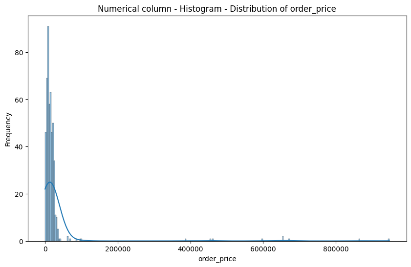

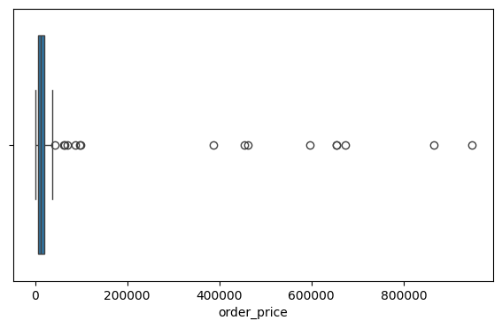

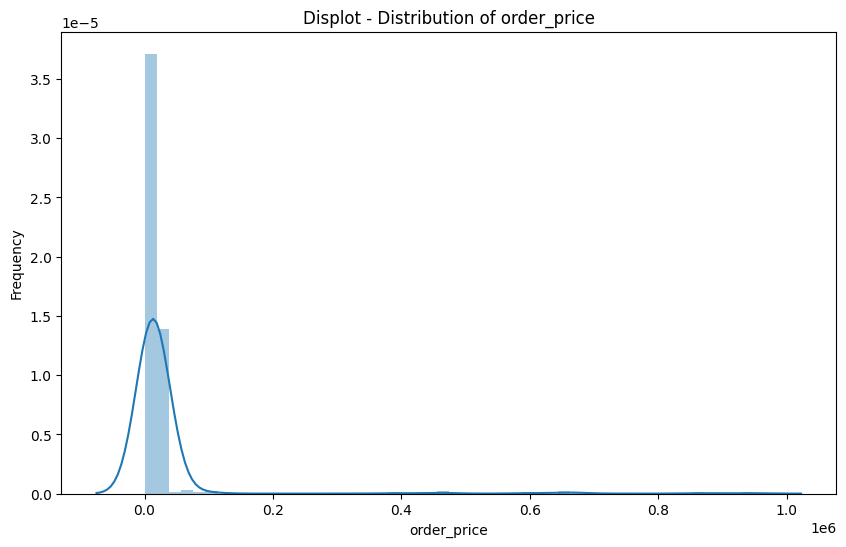

```
Summary statistics for order_price:
count       500.000000
mean      25415.536000
std       86357.715521
min           0.000000
25%        6910.000000
50%       12780.000000
75%       20360.000000
max      947691.000000
Name: order_price, dtype: float64
```

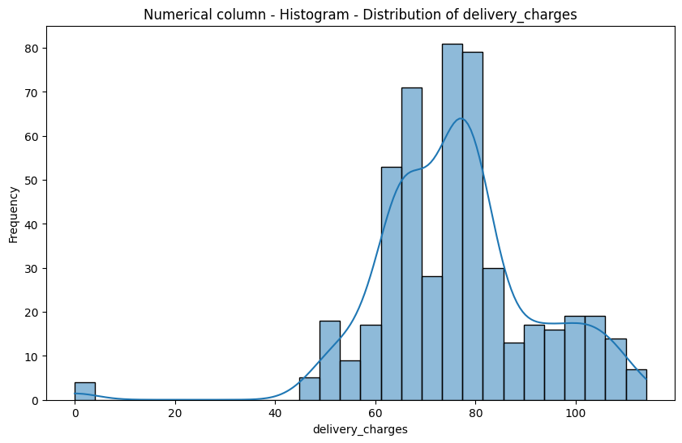

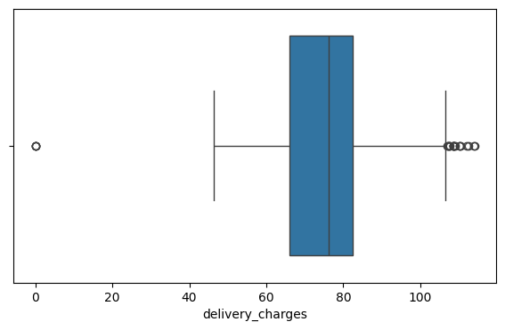

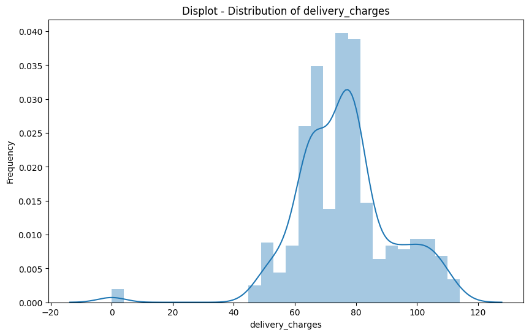

```
Summary statistics for delivery_charges:
count    500.000000
mean      76.132040
std       15.808087
min        0.000000
25%       66.062500
50%       76.290000
75%       82.370000
max      114.040000
Name: delivery_charges, dtype: float64
```

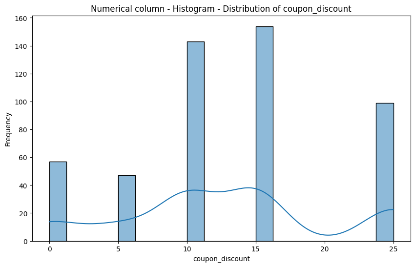

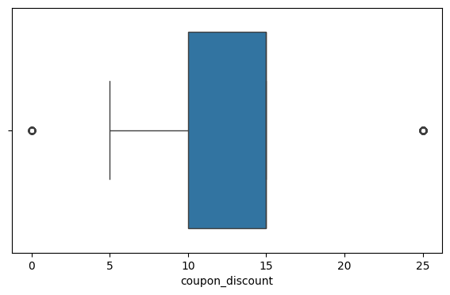

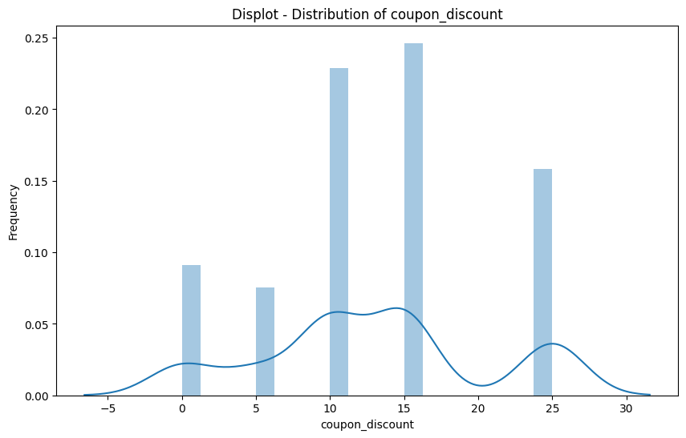

```
Summary statistics for coupon_discount:
count    500.000000
mean      12.900000
std        7.596408
min        0.000000
25%       10.000000
50%       15.000000
75%       15.000000
max       25.000000
Name: coupon_discount, dtype: float64
```

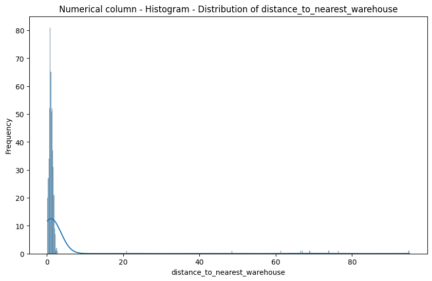

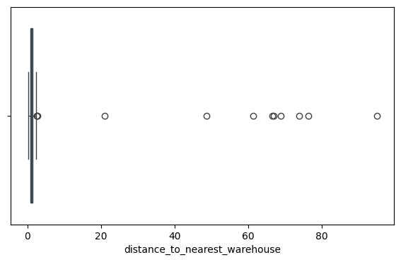

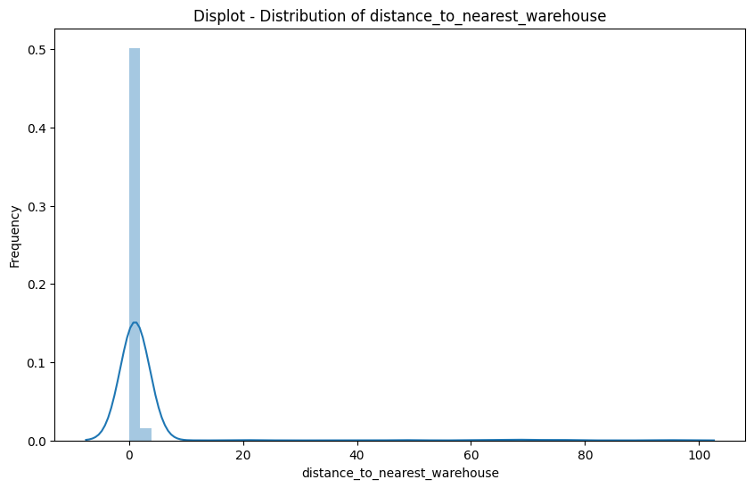

```
Summary statistics for distance_to_nearest_warehouse:
count    500.000000
mean       2.204224
std        8.812416
min        0.107800
25%        0.751425
50%        1.030100
75%        1.408625
max       94.973400
Name: distance_to_nearest_warehouse, dtype: float64
```

[6 more figures not shown]

```
Summary statistics for total_bill:
count       500.000000
mean      22053.444480
std       74547.818104
min          68.240000
25%        6148.380000
50%       11076.745000
75%       17791.850000
max      853012.720000
Name: total_bill, dtype: float64
```

```python
# Perform univariate analysis on each numerical column
for column in numerical_vars_arrays:
    perform_univariate_analysis(dataset, column)
```

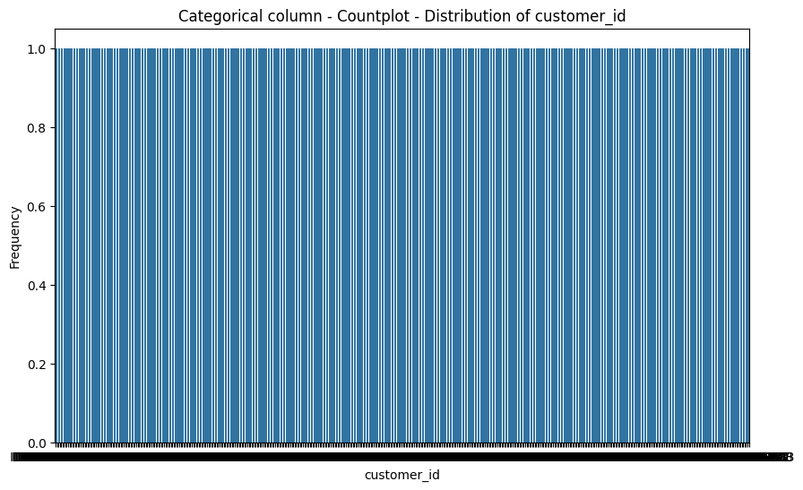

```
Value counts for customer_id:
customer_id
ID0571731474    1
ID0030385740    1
ID1132069617    1
ID0283334330    1
ID5563404259    1
               ..
ID0030385486    1
ID4315295100    1
ID0036822341    1
ID0591320179    1
ID0052450483    1
Name: count, Length: 500, dtype: int64
```

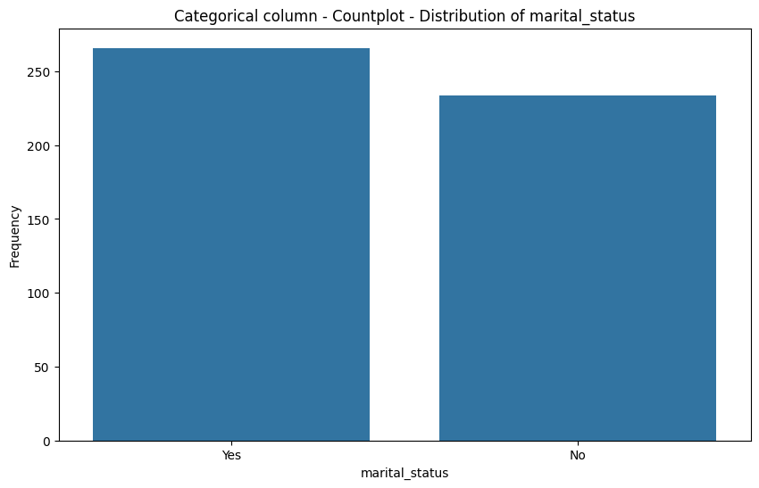

```
Value counts for marital_status:
marital_status
Yes    266
No     234
Name: count, dtype: int64
```

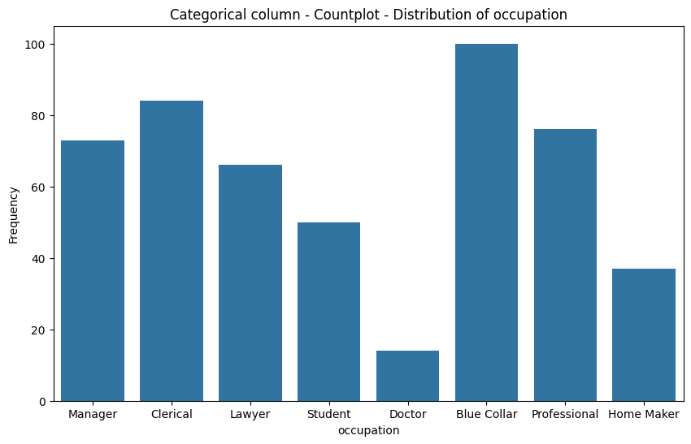

```
Value counts for occupation:
occupation
Blue Collar     100
Clerical         84
Professional     76
Manager          73
Lawyer           66
Student          50
Home Maker       37
Doctor           14
Name: count, dtype: int64
```

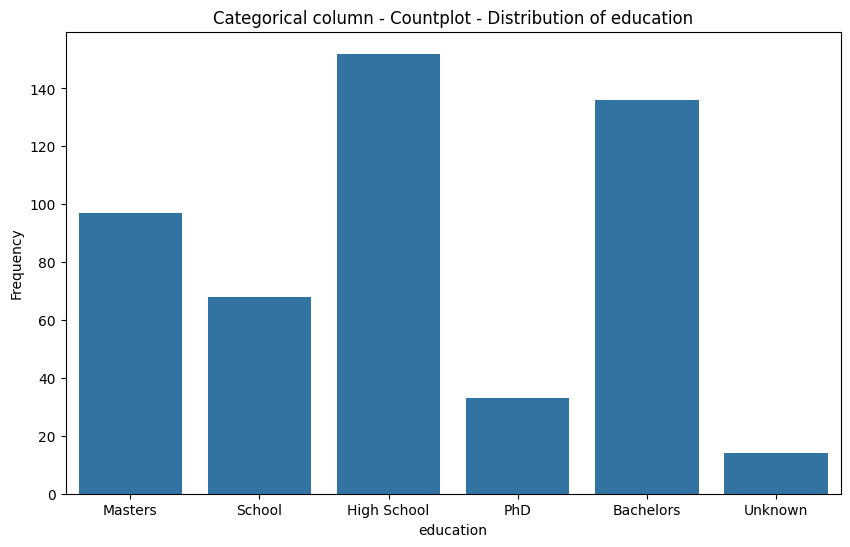

```
Value counts for education:
education
High School    152
Bachelors      136
Masters         97
School          68
PhD             33
Unknown         14
Name: count, dtype: int64
```

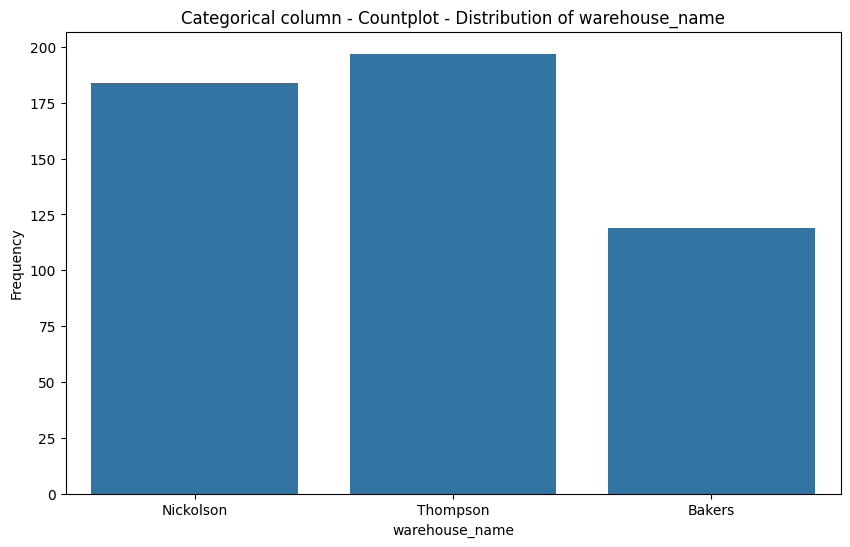

```
Value counts for warehouse_name:
warehouse_name
Thompson     197
Nickolson    184
Bakers       119
Name: count, dtype: int64
```

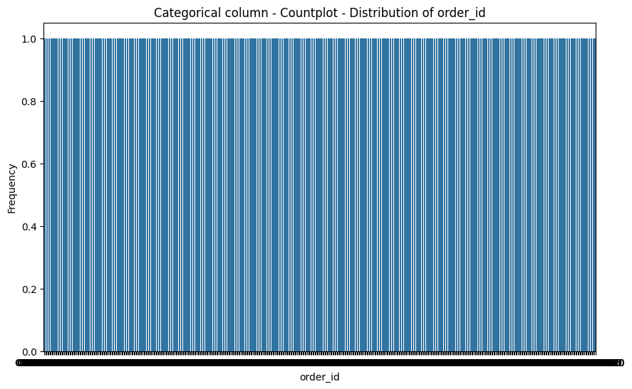

```
Value counts for order_id:
order_id
ORD001041    1
ORD322420    1
ORD334485    1
ORD333990    1
ORD333358    1
            ..
ORD150293    1
ORD146760    1
ORD144784    1
ORD144770    1
ORD499540    1
Name: count, Length: 500, dtype: int64
```

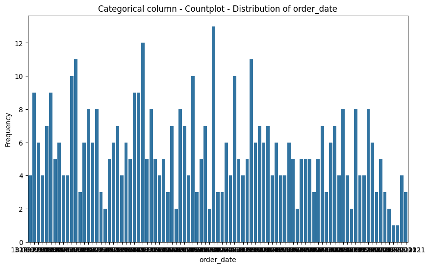

```
Value counts for order_date:
order_date
14-07-2021    13
16-07-2021    12
09-05-2021    11
23-07-2021    11
10-05-2021    10
              ..
30-06-2021     2
28-05-2021     2
19-06-2021     2
02-05-2021     1
01-07-2021     1
Name: count, Length: 91, dtype: int64
```

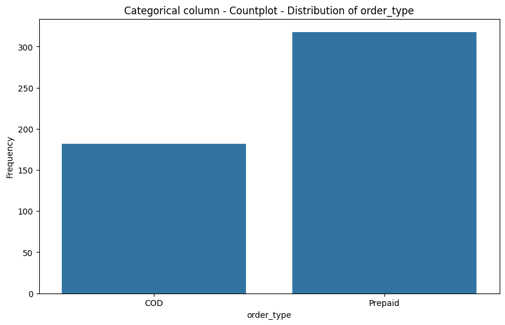

```
Value counts for order_type:
order_type
Prepaid    318
COD        182
Name: count, dtype: int64
```

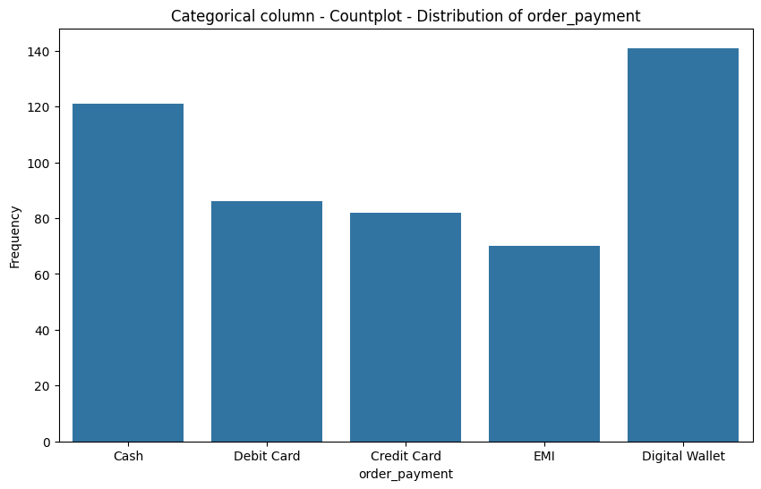

```
Value counts for order_payment:
order_payment
Digital Wallet    141
Cash              121
Debit Card         86
Credit Card        82
EMI                70
Name: count, dtype: int64
```

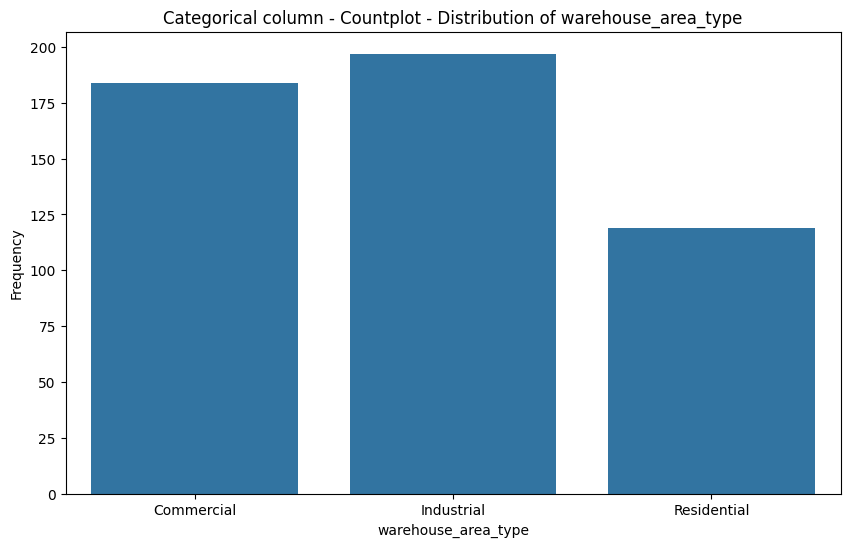

```
Value counts for warehouse_area_type:
warehouse_area_type
Industrial     197
Commercial     184
Residential    119
Name: count, dtype: int64
```

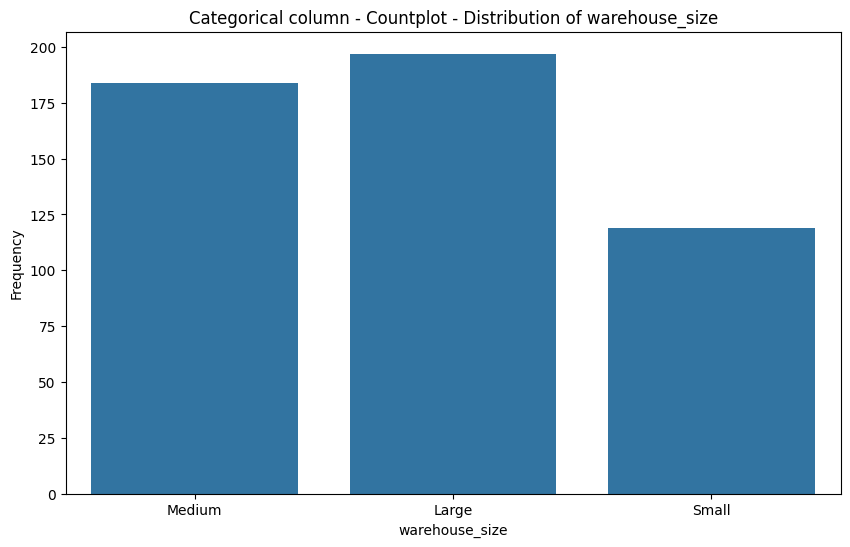

```
Value counts for warehouse_size:
warehouse_size
Large     197
Medium    184
Small     119
Name: count, dtype: int64
```

```python
# Perform univariate analysis on each categorical column
for column in categorical_vars_arrays:
    perform_univariate_analysis(dataset, column)
```

### Observations

- Outliers exist in order prices because different types of products are ordered with varying pricing ranges.
- As you can see in the above graph, there are outliers for delivery charges. This is bacause charges depend on the product and the distance between the customer's residence and the warehouse.
- The majority of customers received a coupon discount of 10 and 15 orders.
- It seems like the column total_bill have some outliers, lets display it with the boxplot to understand the distribution of outliers
- There are lots of outliers in the total bill column as the few products are higher in price.
- There are lots of outliers in the distance_to_nearest_warehouse column. A few customers are way far from the delivery warehouse.
- The number of customers that are marked is greater than that of the unmarried.
- Most of the customer have clues-collar as their occupation.
- Customers with doctors as an occupation have the least number.
- The highest number of customers are high school graduates, followed by bachelor's degrees.
- Major deliveries are done from the ware name "Thompson"
- Major deliveries are made from the warehouse situated in an industrial area.
- Customers prefer the prepaid order type.
- Customers are preferring to pay more in the form of digital wallets and cash.
- Around 52% of the customers i.e. 262 customers, are satisfies and 47% of the customers i.e. 238 customers are not satisfied with the service.

### Bar Graph

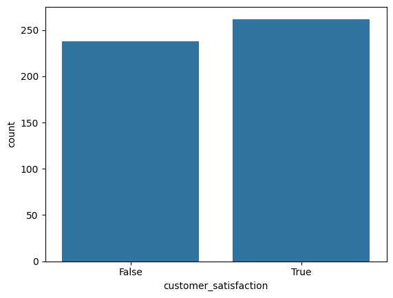

```python
sns.countplot(data=dataset,x='customer_satisfaction')
plt.show()
```

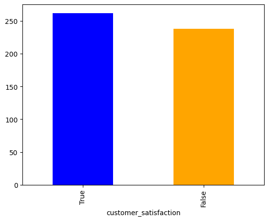

```python
dataset['customer_satisfaction'].value_counts().plot(kind='bar',color=['blue','orange']) # = matplotlib
```

### Pie Chart

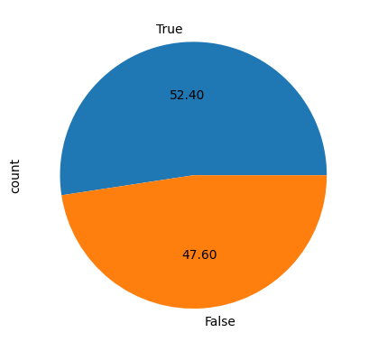

```python
dataset['customer_satisfaction'].value_counts().plot(kind='pie',autopct='%.2f')
```

### Plot the heatmap.

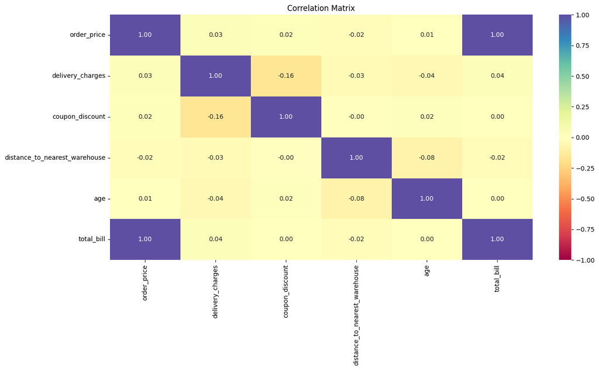

```python
# Exclude non-numeric columns
numeric_columns = dataset.select_dtypes(include=[float, int]).columns
numeric_dataset = dataset[numeric_columns]

# Create a correlation matrix
correlation_matrix = numeric_dataset.corr()

# Plot the correlation matrix as a heatmap
plt.figure(figsize=(15, 7))
sns.heatmap(correlation_matrix, annot=True, vmin=-1, vmax=1, fmt=".2f", cmap="Spectral")
plt.title('Correlation Matrix')
plt.show()
```